# Machine Learning - Final Project

Parker Finn

August 13, 2016

## Executive Summary

This project uses data collected from six individuals to model and predict the quality of a weightlifting exercise. The data was collected from accelerometers on the belt, forearm, arm, and dumbell of each participant. The original study collected data as each individual performed dumbbell curls according to five different specifications:

- exactly according to the specification (Class A)
- throwing the elbows to the front (Class B)
- lifting the dumbbell only halfway (Class C)
- lowering the dumbbell only halfway (Class D)
- throwing the hips to the front (Class E)

Using the train function from the Caret package, an rpart model was tested followed by a Random Forest model. The Random Forest model successfully predicts the class with very high accuracy.

Data is from the WLE dataset from the Qualitative Activity Recognition of Weight Lifting Exercises study. (http://groupware.les.inf.puc-rio.br/har)

### Evaluation of Data

```r
testing <- read.csv("pml-testing.csv")
training <- read.csv("pml-training.csv")
```

The training data set includes 19,622 observations and 160 variables. Fields include the subject’s name and the quality of their lifting, labeled as “classe” and coded with A, B, C, D or E.

```
##
##     adelmo carlitos charles eurico jeremy pedro
##   A   1165      834     899    865   1177   640
##   B    776      690     745    592    489   505
##   C    750      493     539    489    652   499
##   D    515      486     642    582    522   469
##   E    686      609     711    542    562   497
```

The first seven variables include time stamps, user names and other data not necessary for the analysis. These are removed. Many variables appear to be unnecessary derivatives of other variables.

The data is further refined by checking for zero or near zero variance predictors. 59 variables are found to be near zero varianec, i.e. they have few unique values relative to the number of samples and one value dominates. They will likely not add to the analysis and are removed.

```r
#Check for near zero covariates
nsv <- nearZeroVar(training1, saveMetrics = T)
table(nsv[,"nzv"])
```

```
##
## FALSE  TRUE
##    94    59
```

```r
#Keep fields that are "false" for near zero variance
training2 <- training1[, nsv[,"nzv"]==FALSE]
```

A large number of variables remain with high NA counts. For each, there are 19,216 NA and 406 values, or nearly 98% of the data as NA. On inspection it seems clear that these variables are calculated from the other variables, presenting values such as standard deviation, max and min. These are removed to produce a final data set of 19,622 observations with 53 variables.

```r
# Remove fields with high NA
highNA <- sapply(training2, function(x) sum(is.na(x))) == 19216

table(highNA)
```

```
## highNA
## FALSE  TRUE
##    53    41
```

```r
training3 <- training2[, highNA==FALSE]
```

### Create Training and Test Set for Evaluation

The resulting data is split into a new training set (60%) and testing set (40%) for model evaluation and testing. The “classe” variable, which will be predicted, is set as the outcome in the partition.

The new training set has 11,776 observations. The new test set has 7,846 observations.

```r
set.seed(987)
data <- createDataPartition(training3$classe, p = 0.6, list = F)

trainingNew <- training3[data,]
testingNew <- training3[-data,]
```

### RPART Model

The first model uses the Caret package to train a model using the rpart method. Default train control settings are used.

This model is a poor predictor. The best tuning of cp = 0.041 only produces Accuracy of 48%.

```r
set.seed(1234)
mod1 <- train(classe ~ ., data = trainingNew, method = "rpart")
mod1
```

```
## CART
##
## 11776 samples
##    52 predictor
##     5 classes: 'A', 'B', 'C', 'D', 'E'
##
## No pre-processing
## Resampling: Bootstrapped (25 reps)
## Summary of sample sizes: 11776, 11776, 11776, 11776, 11776, 11776, ...
## Resampling results across tuning parameters:
##
##   cp          Accuracy   Kappa
##   0.04105363  0.4844251  0.32276260
##   0.04935928  0.4461580  0.26242132
##   0.11651637  0.3387937  0.08441406
##
## Accuracy was used to select the optimal model using  the largest value.
## The final value used for the model was cp = 0.04105363.
```

```r
table(predict(mod1, trainingNew, type = "raw"), trainingNew$classe)
```

```
##
##        A    B    C    D    E
##   A 3060  968  969  846  315
##   B   65  581   38  361  125
##   C  215  730 1047  723  735
##   D    0    0    0    0    0
##   E    8    0    0    0  990
```

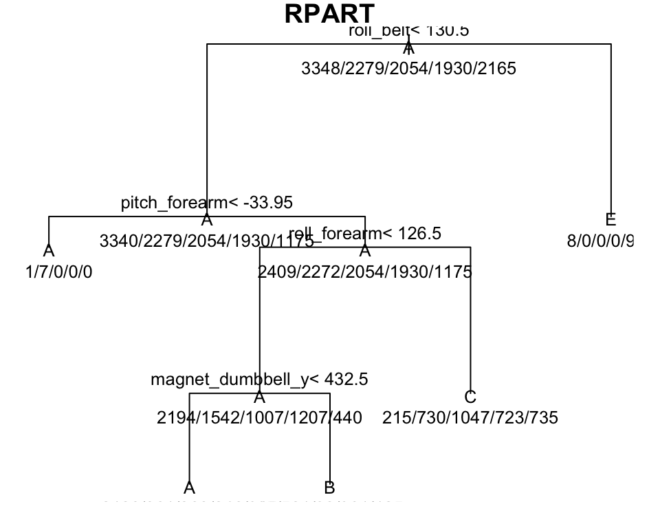

### Random Forest Model

The Random Forest method is used to evaluate the training set. Given the large number of variables, this method is able to optimize a much better model. Cross-validation is used with 5 folds.

The resulting model is highly accurate with an error rate of 0.82% with the training set.

```r
# Random Forest Model
set.seed(1234)
mod2 <- train(classe ~ ., data = trainingNew, method = "rf",
              trControl = trainControl(method="cv", number = 5))

mod2$finalModel
```

```
##
## Call:
##  randomForest(x = x, y = y, mtry = param$mtry)
##                Type of random forest: classification
##                      Number of trees: 500
## No. of variables tried at each split: 2
##
##         OOB estimate of  error rate: 0.82%
## Confusion matrix:
##      A    B    C    D    E  class.error
## A 3345    3    0    0    0 0.0008960573
## B   18 2251   10    0    0 0.0122860904
## C    0   20 2034    0    0 0.0097370983
## D    0    0   34 1895    1 0.0181347150
## E    0    0    7    3 2155 0.0046189376
```

The model has high accuracy at both low and high values of mtry. Variable Importance shows roll_belt and yaw_belt as two influential variables, though many more show importance as well.

```r
mod2$results
```

```
##   mtry  Accuracy     Kappa  AccuracySD     KappaSD
## 1    2 0.9892148 0.9863562 0.003014140 0.003811528
## 2   27 0.9888753 0.9859276 0.002134532 0.002699217
## 3   52 0.9838657 0.9795916 0.002666406 0.003372950
```

```r
varImp(mod2)
```

```
## rf variable importance
##
##   only 20 most important variables shown (out of 52)
##
##                      Overall
## roll_belt             100.00
## yaw_belt               79.07
## magnet_dumbbell_z      69.64
## magnet_dumbbell_y      65.53
## pitch_belt             64.21
## pitch_forearm          59.62
## magnet_dumbbell_x      55.29
## roll_forearm           55.00
## accel_belt_z           48.87
## accel_dumbbell_y       44.64
## roll_dumbbell          43.33
## magnet_belt_y          43.28
## magnet_belt_z          41.06
## accel_dumbbell_z       37.65
## roll_arm               34.91
## accel_forearm_x        34.30
## accel_dumbbell_x       31.43
## yaw_dumbbell           31.28
## gyros_belt_z           31.24
## total_accel_dumbbell   31.16
```

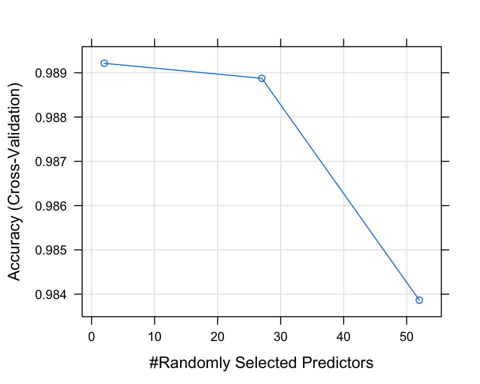

```r
plot(mod2)
```

## Final Result - Evaluating Test Data

Testing the final model on the test data produces excellent results. Accuracy is 99%. (Note that this is the data split from the initial training set, not the test data to be used for the quiz.)

```r
confusionMatrix(predict(mod2, newdata = testingNew), testingNew$classe)
```

```
## Confusion Matrix and Statistics
##
##           Reference
## Prediction    A    B    C    D    E
##          A 2229   13    0    0    0
##          B    3 1499    6    0    0
##          C    0    6 1361   21    5
##          D    0    0    1 1263    6
##          E    0    0    0    2 1431
##
## Overall Statistics
##
##                Accuracy : 0.992
##                  95% CI : (0.9897, 0.9938)
##     No Information Rate : 0.2845
##     P-Value [Acc > NIR] : < 2.2e-16
##
##                   Kappa : 0.9898
##  Mcnemar's Test P-Value : NA
##
## Statistics by Class:
##
##                      Class: A Class: B Class: C Class: D Class: E
## Sensitivity            0.9987   0.9875   0.9949   0.9821   0.9924
## Specificity            0.9977   0.9986   0.9951   0.9989   0.9997
## Pos Pred Value         0.9942   0.9940   0.9770   0.9945   0.9986
## Neg Pred Value         0.9995   0.9970   0.9989   0.9965   0.9983
## Prevalence             0.2845   0.1935   0.1744   0.1639   0.1838
## Detection Rate         0.2841   0.1911   0.1735   0.1610   0.1824
## Detection Prevalence   0.2858   0.1922   0.1775   0.1619   0.1826
## Balanced Accuracy      0.9982   0.9930   0.9950   0.9905   0.9960
```